# Predicting Tournament Success with Stacked Ensemble

Caleb Hyun, Magnus Nielsen, Pari Dar, Aryan Gupta, Jaeyi Kang

December 4, 2025

## 1 Why do we Care?

March Madness is the NCAA’s annual Division I men’s basketball tournament that brings together 64 teams in a single-elimination tournament over the course of a few weeks. The 64 teams are divided into 4 regions - East, West, South, and Midwest - with each region having a team seeded 1-16 (1 seed is the best and 16 seed is the worst). In each region, the 1 seed plays the 16 seed, the 2 seed plays the 15 seed, and so on, until 1 team is left standing in the region. This team represents the region in the “Final Four.”

With frequent upsets - especially in early rounds - and a mix of automatic qualifiers and committee-selected teams, the tournament is very chaotic. Predicting winners is challenging yet significantly valuable, especially in the world of sports betting. This analytics project aims to predict which teams will advance to the Final Four. By identifying key metrics associated with deep tournament runs, this project helps teams understand the drivers of tournament success. In addition, with March Madness being one of the most bet on sporting events every year, this project also offers insights into more profitable and data-driven betting strategies for future tournaments.

## 2 Load the Data

```r
br <- read.csv("march.csv")

# Turn All String into Factor
br[sapply(br, is.character)] <- lapply(br[sapply(br, is.character)], as.factor)

br <- br %>%
  rename(finals = Final.Four.)

br$finals <- ifelse(br$finals == "No", 0, 1)

# Preserve original data with Season and team names for later matching
# We'll filter this the same way as br to keep rows aligned
br_original <- br[, c("Season", "Full.Team.Name")]

summary <- factor(br$finals, levels = c(0, 1), labels = c("No", "Yes"))
y_summary <- br |>
  group_by(finals) |>
  summarise(Count = n()) |>
  mutate(Percent = round(Count / sum(Count) * 100, 1))

kable(y_summary, col.names = c("Finals", "Count", "Percent"))
```

| Finals | Count | Percent |
| --- | --- | --- |
| 0 | 8227 | 98.9 |
| 1 | 88 | 1.1 |

## 3 Clean The Data

Before building our predictive models, the dataset required substantial cleaning to ensure accuracy and consistency. We first filtered the data to only include seasons after 2010 (disregarding 2020 since there was no tournament due to COVID) to maintain comparability across years, as some of the statistics from years prior to 2010 were missing. Next, we removed unnecessary and unusable factors, such as Coach Name, Conference, etc, and excluded metrics that were recorded during the tournament. Redundant columns, specifically those representing rankings for existing raw metrics, were also eliminated to avoid duplication. This filtering process ensures that our models are trained only on pre-tournament data, preventing data leakage that would artificially inflate performance metrics.

```r
br <- br[, !sapply(br, is.factor) | (names(br) %in% c("finals", "Active.Coaching.Length"))]

br <- subset(br, Season > 2010)
br <- subset(br, Season != 2020)

# Filter metadata the same way
br_original <- br_original[br_original$Season > 2010 & br_original$Season != 2020, ]

br$Post.Season.Tournament.Sorting.Index <- NULL

br$Since <- NULL
br$Active.Coaching.Length <- NULL

br <- br[, colSums(is.na(br)) == 0]
# Note: colSums removes columns, not rows, so br_original stays aligned

cols <- grepl("Raw", names(br))
br <- br[, !cols]

cols <- grepl("Rank", names(br))
br <- br[, !cols]
```

```r
br_d <- as.data.frame(model.matrix(~ . -1, data = br))

minmax <- function(x){
  (x - min(x)) / (max(x) - min(x))
}

br_minmax <- as.data.frame(lapply(br_d, minmax))
```

### 3.1 Class Imbalance Visualization

In our sample, we found that 99% of the data do not make it to the final four, meaning that only 1% of them are classified as a Yes. Since models are designed to maximize the accuracy of the predictions, there is high chance that the model follows the naive prediction of No.

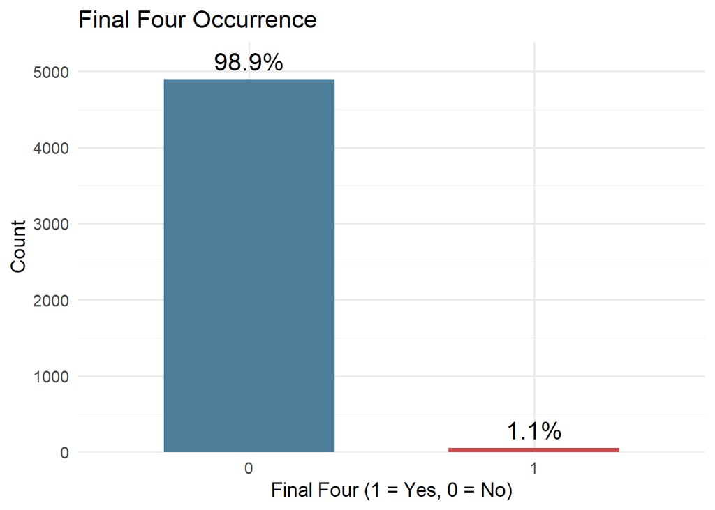

```r
# Class imbalance visualization
df <- data.frame(
  Finals = factor(c(0, 1)),
  Count = c(4898, 52),
  Percent = c(98.9, 1.1)
)

# Bar chart
ggplot(df, aes(x = Finals, y = Count, fill = Finals)) +
  geom_bar(stat = "identity", width = 0.6, show.legend = FALSE) +
  geom_text(aes(label = paste0(Percent, "%")),
            vjust = -0.5,
            size = 6) +
  scale_y_continuous(expand = expansion(mult = c(0, 0.1))) +
  scale_fill_manual(values = c("#4C7D99", "#C94C4C")) +
  labs(
    title = "Final Four Occurrence",
    x = "Final Four (1 = Yes, 0 = No)",
    y = "Count"
  ) +
  theme_minimal(base_size = 14)
```

## 4 Cluster Analysis

To refine the dataset and focus the predictive model on Final Four contenders, we performed a K-Means Clustering analysis. This partitioned the teams into distinct groups based on their performance metrics, allowing us to identify and exclude teams with historically low probabilities of success.

We normalize the data using Min-Max scaling to a 0-1 range, as to not have larger absolute values disproportionately affect smaller data ranges such as percentages. Further, to find the optimal value of K’s we look at cluster sizes and cluster values to reach a level of clustering that accurately and relevantly segments the teams into interpretable performance profiles. The segmentation occurred on regular-season performance metrics, such as, adjusted offense & defense, tempo, shooting efficiency and field goal percentages.

```r
set.seed(12345)

br_cluster_data <- br_minmax[, names(br_minmax) != "finals"]

k4 <- kmeans(br_cluster_data, centers = 4)

br_minmax$cluster <- k4$cluster

br_filtered <- subset(br_minmax, cluster %in% c(1, 3))
br_filtered$cluster <- factor(br_filtered$cluster)

table(br_filtered$cluster)
```

```
##
##    1    3
## 1143  947
```

Now let’s examine key features that differentiate the clusters. We focus on four critical metrics that capture fundamental differences in team performance: Block Percentage (defensive presence), Offensive Efficiency (raw offensive output), Adjusted Offensive Efficiency (pace-adjusted offense), and Net Rating (overall team strength).

```r
# Get all numeric features (excluding finals, cluster, and metadata/temporal variables)
# Exclude Season and other non-performance identifiers
metadata_cols <- c("finals", "cluster", "Season")
feature_cols <- setdiff(names(br_minmax), metadata_cols)

# Calculate means for all features by cluster
cluster_means_all <- br_minmax %>%
  group_by(cluster) %>%
  summarise(across(all_of(feature_cols), ~ mean(.x, na.rm = TRUE)), .groups = 'drop')

# Transpose for better readability (features as rows, clusters as columns)
cluster_means_melted <- melt(cluster_means_all, id.vars = "cluster", variable.name = "Feature", value.name = "Mean")
cluster_means_transposed <- dcast(cluster_means_melted, Feature ~ cluster, value.var = "Mean")
names(cluster_means_transposed)[-1] <- paste0("Cluster_", names(cluster_means_transposed)[-1])

# Select only the specific features of interest
selected_features <- c("BlockPct", "OE", "AdjOE", "Net.Rating")
top_features <- cluster_means_transposed %>%
  filter(Feature %in% selected_features) %>%
  arrange(match(Feature, selected_features))

# Display the selected features
knitr::kable(top_features, digits = 4, caption = "Key Differentiating Features Across Clusters")
```

Key Differentiating Features Across Clusters

| Feature | Cluster_1 | Cluster_2 | Cluster_3 | Cluster_4 |
| --- | --- | --- | --- | --- |
| BlockPct | 0.4783 | 0.4034 | 0.5057 | 0.3868 |
| OE | 0.8600 | 0.7870 | 0.8477 | 0.8004 |
| AdjOE | 0.6388 | 0.4295 | 0.6190 | 0.4563 |
| Net.Rating | 0.6715 | 0.4429 | 0.6747 | 0.4422 |

The features shown above highlight the core differences between team archetypes. Block Percentage distinguishes defensive-oriented teams (Cluster 3 has the highest), while Offensive Efficiency and Adjusted Offensive Efficiency separate elite offensive teams (Cluster 1) from lower-performing clusters. Net Rating provides an overall measure of team strength, with Clusters 1 and 3 (the elite teams) showing significantly higher values than Clusters 2 and 4.

The analysis identified four unique team archetypes, categorized into “Elite” or “Bad”.

**Tier 1: Elite Teams**

**Cluster 1: The Shotmakers (23.1% of teams)**

These teams are the most efficient on offense, excelling from the two-point range and free-throw line. Furthermore, they show willingness to shoot from the three-point range, having the highest FG3Rate. Further these teams generally employ taller and more experienced players than the competition.

**Cluster 3: The Walls (19.1% of teams)**

Defined by elite defense, these teams are the best at limiting opponent shooting efficiency. They have a strong interior presence (highest block percentage) and run a traditional offense that relies less on 3-pointers and more on efficient ball movement.

**Tier 2: Bad Teams**

**Cluster 2: The Underdogs (26.0% of teams)**

This group represents the lowest overall talent level, with the lowest scores in offensive efficiency and height. They suffer from the worst shooting percentages (both 2-point and 3-point) and play a conservative but inefficient offensive style.

**Cluster 4: The Wildfire (31.8% of teams)**

Characterized by “chaos,” these teams have the worst defense (allowing high opponent shooting percentages) and play at the highest pace. They rely heavily on 3-pointers (both taking and allowing them) but lack defensive impact, having the lowest block and steal percentages.

**Outcome from the clustering analysis**

In the following sections we will use the 42% remaining observations to train models to distinguish between good teams and champions-caliber teams to make our final predictions for who will end up in the Final Four.

## 5 Split Train Test (Level 1)

Data Flow Summary:

1. **Load and Clean Data**: Load raw data, clean columns, remove problematic seasons, create dummy variables, and apply min-max scaling.
2. **Cluster Analysis**: Perform K-means clustering (k=4) on the scaled data to identify distinct team performance profiles.
3. **Filter Clusters**: Keep only Clusters 1 and 3 for predictive modeling (removing Clusters 2 and 4).
4. **Split Data**: Divide the filtered data into:
   - **Training Set (70%)**: To train Level 1 models and Level 2 model
   - **Test Set (30%)**: To evaluate ALL models fairly on unseen data
5. **Train Level 1 Models**: Build three models (Logistic Regression, Decision Tree, Random Forest) on the training set. We use cost matrix optimization in Level 2 to handle class imbalance.
6. **Generate Level 1 Predictions**:
   - Predict on **training set**, which will used as features for Level 2 training
   - Predict on **test set**, which will be used for final evaluation
7. **Train Level 2 Model**: Build stacked model using Level 1 predictions from training set. Perform grid search over cost matrix weights to find the optimal cost that maximizes precision.
8. **Evaluate**: Test Level 2 model on test set predictions.

We’ll split the **filtered data (Clusters 1 & 3)** into two sets:

1. **Training Set (70%)**: To train Level 1 models and the Level 2 (Stacked) model.
2. **Test Set (30%)**: To evaluate ALL models fairly on unseen data.

Given the extreme class imbalance (~99% “No”, ~1% “Yes”), we decided to try **cost matrix optimization** in Level 2 to handle the imbalance, rather than upsampling. We perform a grid search over a wide range of cost weights to find the optimal cost that maximizes precision on the training set while ensuring predictions are made. This approach would penalize false positives directly during model training.

```r
set.seed(12345)

train_idx <- sample(1:nrow(br_filtered), 0.7 * nrow(br_filtered))
train_raw <- br_filtered[train_idx, ]
test <- br_filtered[-train_idx, ]

train_raw$finals <- factor(train_raw$finals, levels = c(0,1), labels = c("No", "Yes"))
test$finals <- factor(test$finals, levels = c(0,1), labels = c("No", "Yes"))

train_raw$cluster <- NULL
test$cluster <- NULL

train <- train_raw

filtered_indices <- which(br_minmax$cluster %in% c(1, 3))

test_indices_in_filtered <- setdiff(1:nrow(br_filtered), train_idx)
test_indices_in_original <- filtered_indices[test_indices_in_filtered]

test_metadata <- br_original[test_indices_in_original, ]

# table(train$finals)
```

We tried to use cost matrix optimization to handle class imbalance by penalizing false positives during model training. However, cost matrix optimization has fundamental limitations for maximizing precision. As the false positive cost increases, the model becomes increasingly conservative. Beyond a certain threshold (approximately cost = 20 in our analysis), the model stopped making any positive predictions entirely, resulting in zero precision rather than improved precision. This occurs because the cost matrix penalizes false positives so heavily that the optimal strategy becomes predicting “No” for all cases, which minimizes total cost but eliminates all positive predictions.

This visualization of our grid search results demonstrates this phenomenon: our precision remains high (around 0.975) for costs from 1 to 15, but then drops abruptly to zero at cost = 20 and remains zero for all higher cost values. This behavior showed us that the cost matrix approach can’t fine-tune precision beyond a certain point. Therefore, we chose the cost value that produces the highest precision among costs that still generate predictions, rather than attempting to maximize precision directly through cost matrix tuning.

## 6 Build Level 1 Models

We build three separate models on the training data: Logistic Regression, Decision Tree, and Random Forest. These models serve as base learners in our stacked ensemble approach, each capturing different aspects of the relationship between team performance metrics and Final Four success.

### 6.1 Logistic Regression

We start with a full logistic regression model. This model works well here because it’s built to give clear, interpretable probabilities instead of just a hard yes or no. It shows how each variable pushes a team closer to or farther from making the Final Four. Because it’s a simple, low-variance model, it doesn’t overfit as easily as more complex ones, which matters in this dataset since positive cases are extremely rare. It also provides calibrated probability outputs that make it especially useful as a base learner in a stacked model, since the second level can meaningfully use those probabilities as inputs.

```r
log_model <- glm(finals ~ ., data = train, family = binomial)
```

### 6.2 K-Nearest Neighbors

KNN isn’t used in our modeling because it performs poorly with extreme class imbalance. Since it classifies a new point by looking at its closest neighbors, we found that negative cases dominate almost every neighborhood, causing the model to predict “No” nearly all the time. It also depends heavily on distance, which becomes unreliable in high-dimensional, highly correlated sports data. Because of these issues, KNN would add noise rather than value to a stacked model, so we’ve commented it out.

### 6.3 Support Vector Machine (SVM)

Much like KNN, SVM with an RBF kernel also struggles when one class overwhelmingly outnumbers the other. The model tries to find a boundary that separates the classes, but with so few “Yes” cases, the rare class gets overshadowed and the boundary ends up favoring the majority class. Tuning SVMs for imbalance requires extensive parameter adjustments and specialized class weighting, which adds complexity without guaranteeing meaningful gains. Given these issues, we excluded SVM from the final stack to keep the pipeline efficient and focused on models that learn better from this heavily skewed dataset.

### 6.4 Decision Tree (C5.0)

Next, we build the standard C5.0 Decision Tree. Decision trees are easy to interpret and can pick up nonlinear relationships that logistic regression might miss. They work by repeatedly splitting the data into smaller groups based on the features that best separate the classes. However, because the minority class is so small, the tree can end up biased toward predicting the majority class, which is why it performs worse than expected in this problem.

```r
dt_model <- C5.0(
  x = train[, -which(names(train) == "finals")],
  y = train$finals
)
```

### 6.5 Random Forest

We also add a RandomForest model, which creates many decision trees and averages their predictions to improve stability. This approach usually boosts accuracy because it reduces the noise and overfitting that single trees struggle with. Random Forests can capture complex interactions between variables, making them strong general-purpose classifiers.

```r
rf_model <- randomForest(
  finals ~ .,
  data = train,
  ntree = 200,
  importance = TRUE
)
```

## 7 Level 1 Predictions and Evaluation

We generate predictions on the Test Set for evaluation, and on the Training Set to prepare for Level 2 training. The training set predictions serve as features for the Level 2 meta-model, while test set predictions allow us to evaluate each Level 1 model’s performance independently before stacking.

```r
log_probs <- predict(log_model, test, type = "response")
log_pred <- ifelse(log_probs > 0.5, "Yes", "No")
log_pred <- factor(log_pred, levels = c("No", "Yes"))

dt_pred <- predict(dt_model, test)
dt_probs_matrix <- predict(dt_model, test, type = "prob")
dt_probs <- dt_probs_matrix[, "Yes"]

rf_pred <- predict(rf_model, test)
rf_probs_matrix <- predict(rf_model, test, type = "prob")
rf_probs <- rf_probs_matrix[, "Yes"]

cm_log <- confusionMatrix(log_pred, test$finals, positive = "Yes")
cm_log$table
```

```
##           Reference
## Prediction  No Yes
##        No  598   7
##        Yes  13   9
```

```r
cm_dt  <- confusionMatrix(dt_pred, test$finals, positive = "Yes")
cm_dt$table
```

```
##           Reference
## Prediction  No Yes
##        No  600  13
##        Yes  11   3
```

```r
cm_rf  <- confusionMatrix(rf_pred, test$finals, positive = "Yes")
cm_rf$table
```

```
##           Reference
## Prediction  No Yes
##        No  610  14
##        Yes   1   2
```

```r
l1_results <- data.frame(
  Model = c("Logistic Regression", "Decision Tree", "Random Forest"),
  Kappa = c(cm_log$overall["Kappa"], cm_dt$overall["Kappa"], cm_rf$overall["Kappa"]),
  Accuracy = c(cm_log$overall["Accuracy"], cm_dt$overall["Accuracy"], cm_rf$overall["Accuracy"]),
  Sensitivity = c(cm_log$byClass["Sensitivity"], cm_dt$byClass["Sensitivity"], cm_rf$byClass["Sensitivity"]),
  Precision = c(cm_log$byClass["Precision"], cm_dt$byClass["Precision"], cm_rf$byClass["Precision"])
)

kable(l1_results, digits = 3)
```

| Model | Kappa | Accuracy | Sensitivity | Precision |
| --- | --- | --- | --- | --- |
| Logistic Regression | 0.458 | 0.968 | 0.562 | 0.409 |
| Decision Tree | 0.180 | 0.962 | 0.188 | 0.214 |
| Random Forest | 0.204 | 0.976 | 0.125 | 0.667 |

```r
log_probs_train <- predict(log_model, train, type = "response")
dt_probs_train <- predict(dt_model, train, type = "prob")[, "Yes"]
rf_probs_train <- predict(rf_model, train, type = "prob")[, "Yes"]
```

## 8 Build Level 2 Model (Stacking)

Individual models exhibit inherent biases. We created a stacked ensemble model by using Level 1 model predictions as inputs to a meta-model at Level 2. Stacking leverages the strengths of multiple models while mitigating their individual weaknesses.

We used the Training Set predictions to train this meta-model. Level 2 learns how to combine Level 1 predictions, and is evaluated on test set predictions to avoid data leakage. This two-stage approach ensures that the meta-model learns the optimal way to weight and combine the base model predictions without seeing the test data.

```r
l2_train <- data.frame(
  LR_Prob = log_probs_train,
  DT_Prob = dt_probs_train,
  RF_Prob = rf_probs_train,
  finals = train$finals
)
```

```r
set.seed(12345)
folds <- createFolds(train$finals, k = 5, list = TRUE)
```

C5.0 control parameters:

```r
c5_control <- C5.0Control(
  winnow = FALSE,
  noGlobalPruning = FALSE,
  CF = 0.25,
  minCases = 10,
  sample = 0.9,
  earlyStopping = TRUE
)
```

```r
evaluate_cost_cv <- function(cost_val, train_data, actual, folds_list) {
  # Cost matrix format: rows = predicted, columns = actual
  cm_costs <- matrix(c(0, 1, cost_val, 0), nrow = 2, byrow = TRUE)
  rownames(cm_costs) <- c("No", "Yes")
  colnames(cm_costs) <- c("No", "Yes")

  cv_precisions <- numeric(length(folds_list))
  cv_num_preds <- numeric(length(folds_list))

  for(i in 1:length(folds_list)) {
    fold_idx <- folds_list[[i]]
    train_fold <- train_data[-fold_idx, ]
    val_fold <- train_data[fold_idx, ]

    # Train on fold
    mod <- C5.0(
      x = train_fold[, -which(names(train_fold) == "finals")],
      y = train_fold$finals,
      costs = cm_costs,
      control = c5_control
    )

    # Predict on validation fold
    preds <- predict(mod, val_fold[, -which(names(val_fold) == "finals")])

    # Metrics
    n_pos <- sum(preds == "Yes")
    cv_num_preds[i] <- n_pos

    if(n_pos > 0) {
      cm <- confusionMatrix(preds, actual[fold_idx], positive = "Yes")
      prec <- cm$byClass["Precision"]
      cv_precisions[i] <- ifelse(is.na(prec), 0, prec)
    } else {
      cv_precisions[i] <- 0
    }
  }

  return(list(
    cost = cost_val,
    avg_preds = mean(cv_num_preds),
    avg_precision = mean(cv_precisions)
  ))
}
```

```r
cost_candidates <- c(1, 5, 10, 15, 20, 25, 30, 35, 40, 45, 50, 60, 75, 100)
results_df <- data.frame(Cost=numeric(), CV_Precision=numeric(), Avg_Predictions=numeric())

for(c in cost_candidates) {
  res <- evaluate_cost_cv(c, l2_train, train$finals, folds)
  results_df <- rbind(results_df, data.frame(
    Cost = c,
    CV_Precision = res$avg_precision,
    Avg_Predictions = res$avg_preds
  ))
}

valid_results <- results_df[results_df$Avg_Predictions >= 0.2, ]

if(nrow(valid_results) > 0) {
  valid_results <- valid_results[order(-valid_results$CV_Precision, valid_results$Avg_Predictions), ]
  best_result <- valid_results[1, ]
  best_cost <- best_result$Cost
} else {
  best_cost <- 1
}
```

The cost matrix optimization process revealed an important trade-off between training performance and generalization. During cross-validation on the training set, we achieved excellent precision (0.975) with cost values between 5 and 15, which suggested that the model was successfully learning to minimize false positives. However, this high precision on the training data was indicative of overfitting. The cost matrix optimization led the model to become overly conservative and tuned to the specific patterns present in the training set, rather than learning generalizable rules that would transfer to unseen data. We decided to use a cost value of 5, but this did not work well for our test data (maybe because we just didn’t have enough data: in total, we only had .7*14*4 = 39 final four teams in the training data, and .3*14*4 = 17 final four teams in the test data).

```r
final_costs <- matrix(c(0, 1, best_cost, 0), nrow = 2, byrow = TRUE)
rownames(final_costs) <- c("No", "Yes")
colnames(final_costs) <- c("No", "Yes")

l2_model <- C5.0(
  x = l2_train[, -which(names(l2_train) == "finals")],
  y = l2_train$finals,
  costs = final_costs,
  control = c5_control
)

l2_pred_train <- predict(l2_model, l2_train[, -which(names(l2_train) == "finals")])

l2_cm_train <- confusionMatrix(l2_pred_train, train$finals, positive = "Yes")
```

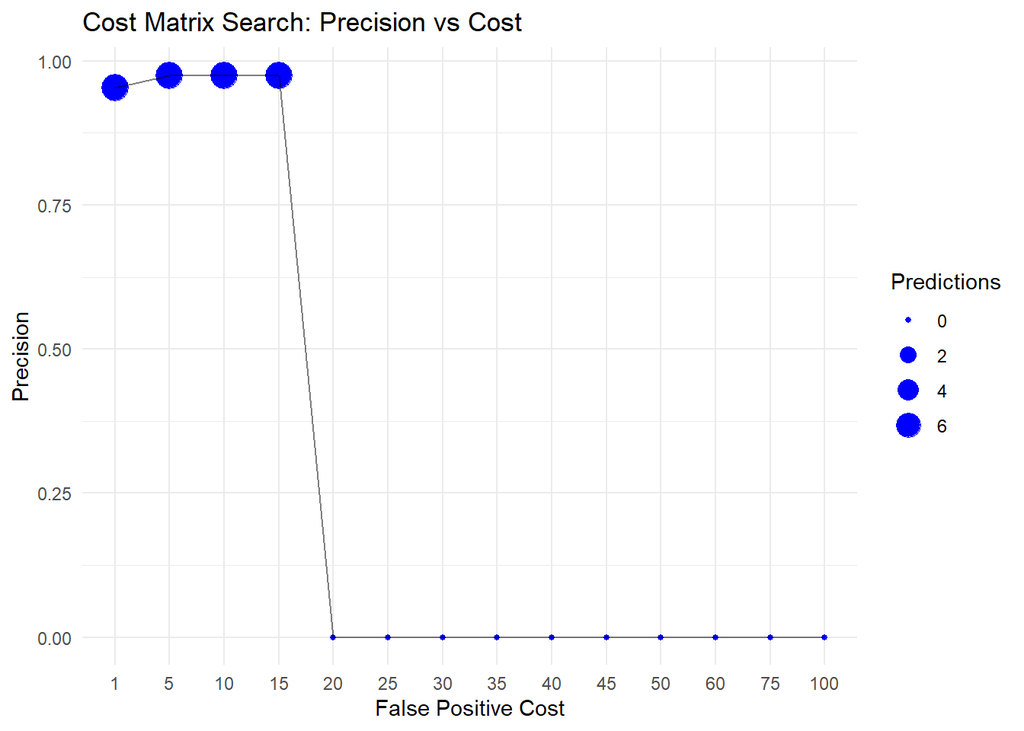

```r
ggplot(results_df, aes(x = factor(Cost), y = CV_Precision)) +
  geom_point(aes(size = Avg_Predictions), color = "blue") +
  geom_line(group = 1, alpha = 0.5) +
  labs(title = "Cost Matrix Search: Precision vs Cost",
       x = "False Positive Cost",
       y = "Precision",
       size = "Predictions") +
  theme_minimal()
```

```r
tryCatch({
  plot(l2_model)
}, error = function(e) {
  invisible(NULL)
})
```

## 9 Level 2 Predictions and Evaluation

We predict the Level 2 model on the Test Set and evaluate performance. This allows for fair comparison with the Level 1 models evaluated in Section 7.

```r
l2_test_input <- data.frame(
  LR_Prob = log_probs,
  DT_Prob = dt_probs,
  RF_Prob = rf_probs,
  finals = test$finals
)

l2_pred <- predict(l2_model, l2_test_input[, -which(names(l2_test_input) == "finals")])
```

```r
if(sum(l2_pred == "Yes") == 0) {
  temp_model <- C5.0(
    x = l2_train[, -which(names(l2_train) == "finals")],
    y = l2_train$finals
  )
  temp_probs <- predict(temp_model, l2_test_input[, -which(names(l2_test_input) == "finals")], type="prob")[,"Yes"]
  max_idx <- which.max(temp_probs)
  l2_pred[max_idx] <- "Yes"
}
```

```r
l2_cm <- confusionMatrix(l2_pred, test$finals, positive = "Yes")
l2_cm$table
```

```
##           Reference
## Prediction  No Yes
##        No  600  10
##        Yes  11   6
```

## 9.1 Final Four Prediction Analysis

We analyze which Final Four teams were correctly predicted, incorrectly predicted, and missed. Team names and seasons are added after predictions are made to avoid changes to the test data.

```r
results_df <- data.frame(
  Season = test_metadata$Season,
  Team = test_metadata$Full.Team.Name,
  Predicted = l2_pred,
  Actual = test$finals
)

correctly_predicted <- results_df[results_df$Predicted == "Yes" & results_df$Actual == "Yes", ]
```

**Correctly predicted Final Four teams:**

```r
if(nrow(correctly_predicted) > 0) {
  correctly_predicted[, c("Season", "Team")]
} else {
  data.frame(Season = numeric(), Team = character())
}
```

```
##    Season                   Team
## 4    2021           Baylor Bears
## 5    2015      Wisconsin Badgers
## 6    2015       Duke Blue Devils
## 11   2019 Texas Tech Red Raiders
## 12   2023          UConn Huskies
## 62   2014          UConn Huskies
```

**Incorrectly predicted Final Four teams (False Positives):**

```r
incorrectly_predicted <- results_df[results_df$Predicted == "Yes" & results_df$Actual == "No", ]
if(nrow(incorrectly_predicted) > 0) {
  incorrectly_predicted[, c("Season", "Team")]
} else {
  data.frame(Season = numeric(), Team = character())
}
```

```
##     Season                   Team
## 2     2025        Houston Cougars
## 3     2025          Auburn Tigers
## 18    2021            USC Trojans
## 25    2011      Wisconsin Badgers
## 27    2025    Purdue Boilermakers
## 37    2019        Houston Cougars
## 53    2016 Wichita State Shockers
## 54    2013      Wisconsin Badgers
## 66    2013     Creighton Bluejays
## 189   2025         Drake Bulldogs
## 204   2018        Syracuse Orange
```

**Missed Final Four teams (False Negatives):**

```r
missed <- results_df[results_df$Predicted == "No" & results_df$Actual == "Yes", ]
if(nrow(missed) > 0) {
  missed[, c("Season", "Team")]
} else {
  data.frame(Season = numeric(), Team = character())
}
```

```
##     Season                     Team
## 1     2015        Kentucky Wildcats
## 9     2019  Michigan State Spartans
## 15    2014           Florida Gators
## 19    2022          Kansas Jayhawks
## 68    2015  Michigan State Spartans
## 82    2022 North Carolina Tar Heels
## 101   2023    Florida Atlantic Owls
## 111   2016          Syracuse Orange
## 124   2023         Miami Hurricanes
## 156   2011          Butler Bulldogs
```

## 9.2 Confusion Matrix Visualizations

We created confusion matrices for all models to understand their performance.

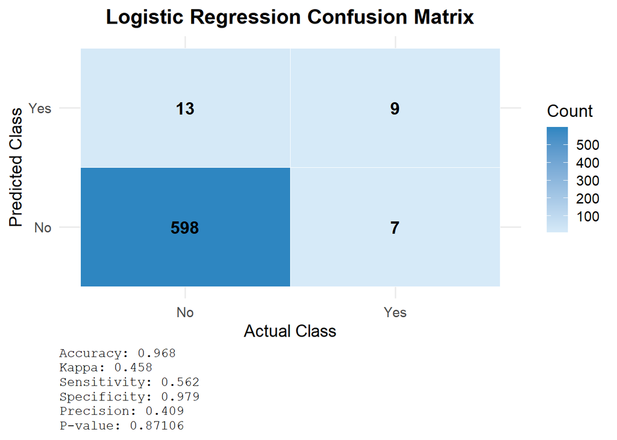

```r
library(stringr)

plot_cm <- function(cm, title = "Confusion Matrix") {
  cm_df <- as.data.frame(cm$table)
  colnames(cm_df) <- c("Prediction", "Reference", "Freq")

  acc  <- round(cm$overall["Accuracy"], 3)
  kap  <- round(cm$overall["Kappa"], 3)
  sens <- round(cm$byClass["Sensitivity"], 3)
  spec <- round(cm$byClass["Specificity"], 3)
  prec <- round(cm$byClass["Precision"], 3)
  pval <- round(cm$overall["AccuracyPValue"], 5)

  stats_text <- paste(
    "Accuracy:", acc,
    "\nKappa:", kap,
    "\nSensitivity:", sens,
    "\nSpecificity:", spec,
    "\nPrecision:", prec,
    "\nP-value:", pval
  )

  ggplot(cm_df, aes(x = Reference, y = Prediction, fill = Freq)) +
    geom_tile(color = "white") +
    geom_text(aes(label = Freq), size = 5, fontface = "bold") +
    scale_fill_gradient(low = "#D6EAF8", high = "#2E86C1") +
    labs(
      title = title,
      x = "Actual Class",
      y = "Predicted Class",
      fill = "Count",
      caption = stats_text
    ) +
    theme_minimal(base_size = 14) +
    theme(
      plot.title = element_text(hjust = 0.5, face = "bold"),
      plot.caption = element_text(hjust = 0, size = 11, family = "mono")
    )
}

# Plot confusion matrices for all models
plot_cm(cm_log, title = "Logistic Regression Confusion Matrix")
```

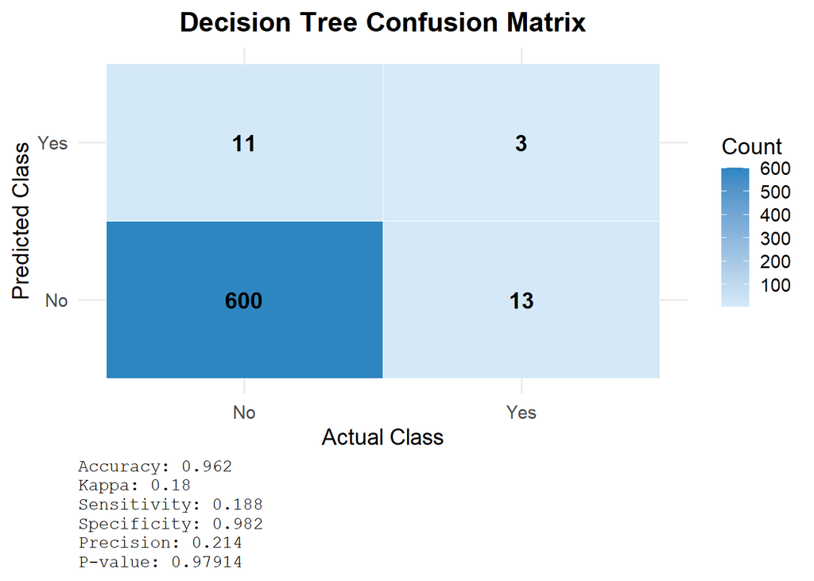

```r
plot_cm(cm_dt, title = "Decision Tree Confusion Matrix")
```

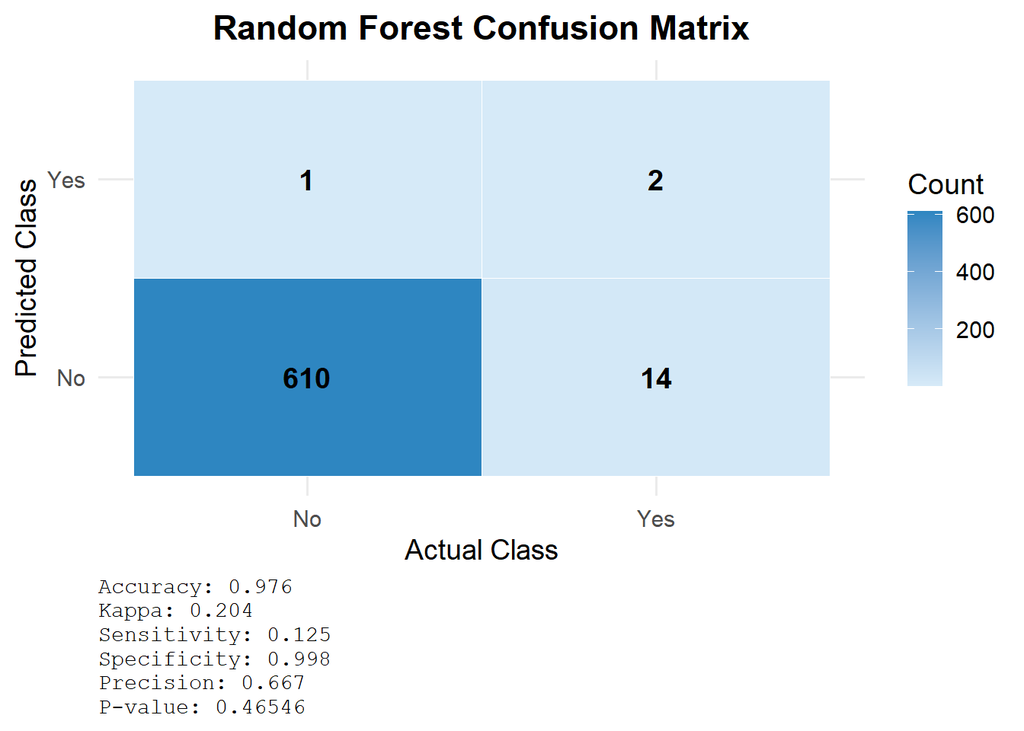

```r
plot_cm(cm_rf, title = "Random Forest Confusion Matrix")
```

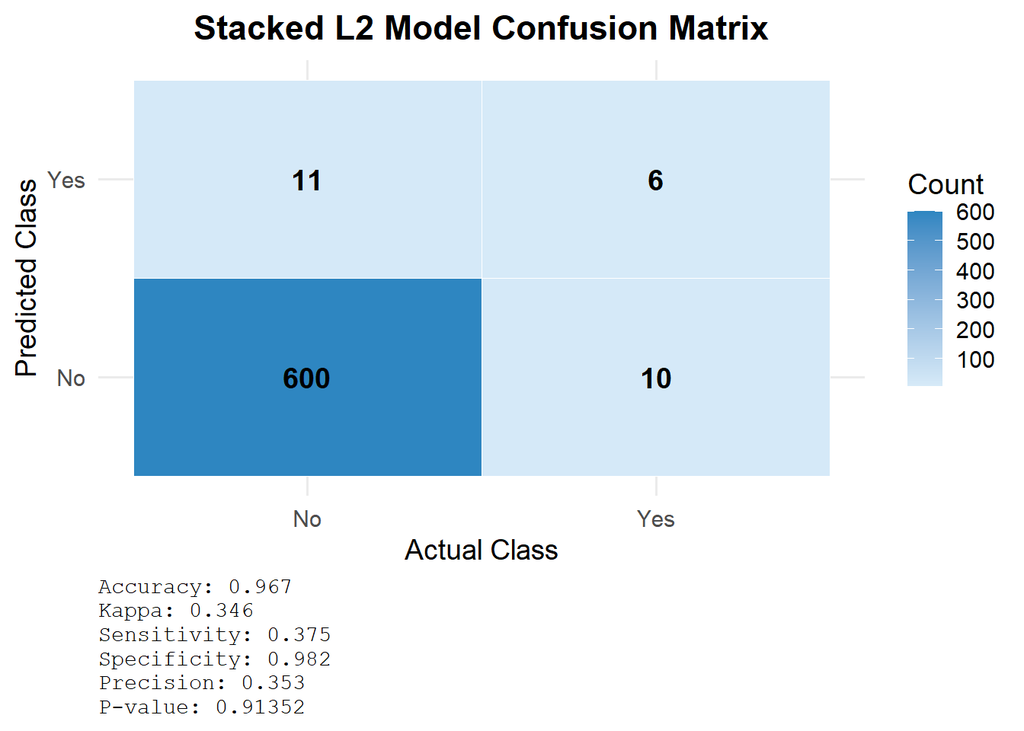

```r
plot_cm(l2_cm, title = "Stacked L2 Model Confusion Matrix")
```

## 9.3 Model Comparison Visualization

We compare all models across multiple metrics including precision.

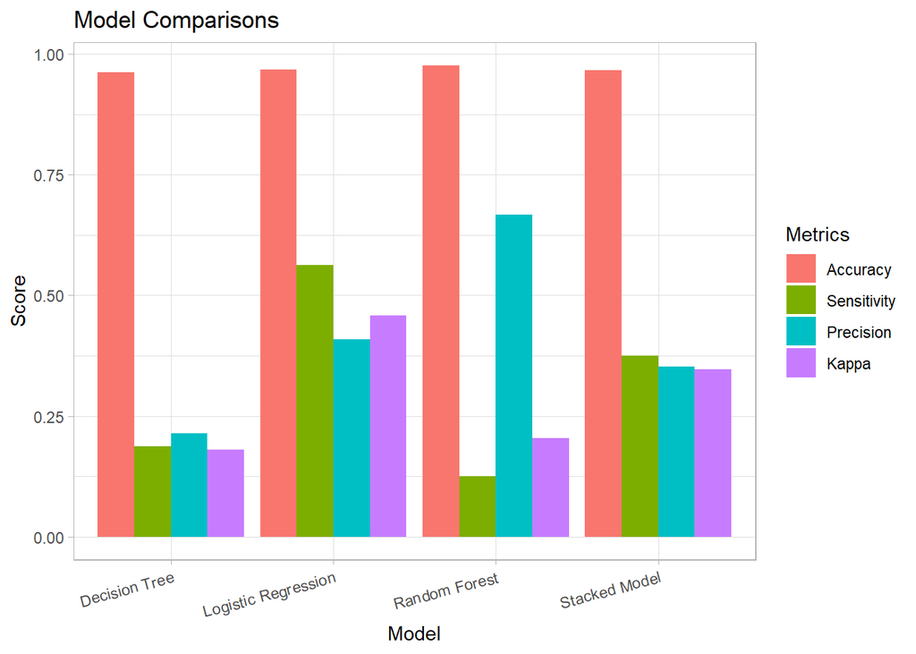

```r
compare_models <- function(cm_list, model_names = NULL, title = "Model Comparison") {
  if (is.null(model_names)) {
    model_names <- paste0("Model_", seq_along(cm_list))
  }

  if (length(model_names) != length(cm_list)) {
    stop("Length of model_names must match number of confusion matrices.")
  }

  metrics_df <- data.frame(
    Model = model_names,
    Accuracy = sapply(cm_list, function(cm) cm$overall["Accuracy"]),
    Sensitivity = sapply(cm_list, function(cm) cm$byClass["Sensitivity"]),
    Precision = sapply(cm_list, function(cm) cm$byClass["Precision"]),
    Kappa = sapply(cm_list, function(cm) cm$overall["Kappa"])
  )

  metrics_melted <- melt(metrics_df, id.vars = "Model")

  ggplot(metrics_melted, aes(x = Model, y = value, fill = variable)) +
    geom_bar(stat = "identity", position = "dodge") +
    labs(title = title,
         y = "Score",
         fill = "Metrics") +
    theme_light() +
    theme(axis.text.x = element_text(angle = 15, hjust = 1))
}

cm_list <- list(
  cm_log,           # Logistic Regression
  cm_dt,            # Decision Tree
  cm_rf,            # Random Forest
  l2_cm             # Stacked Model
)

model_names <- c(
  "Logistic Regression",
  "Decision Tree",
  "Random Forest",
  "Stacked Model"
)

compare_models(cm_list, model_names, title = "Model Comparisons")
```

## 10 Comparison and Summary

First, we’ll look at the Kappas of all models.

```r
final_comparison <- rbind(
  l1_results,
  data.frame(Model = "Stacked L2 (Cost Matrix Optimized)",
             Kappa = l2_cm$overall["Kappa"],
             Accuracy = l2_cm$overall["Accuracy"],
             Sensitivity = l2_cm$byClass["Sensitivity"],
             Precision = l2_cm$byClass["Precision"])
)

kable(final_comparison[order(-final_comparison$Kappa), ], digits = 3)
```

|  | Model | Kappa | Accuracy | Sensitivity | Precision |
| --- | --- | --- | --- | --- | --- |
| 1 | Logistic Regression | 0.458 | 0.968 | 0.562 | 0.409 |
| Kappa | Stacked L2 (Cost Matrix Optimized) | 0.346 | 0.967 | 0.375 | 0.353 |
| 3 | Random Forest | 0.204 | 0.976 | 0.125 | 0.667 |
| 2 | Decision Tree | 0.180 | 0.962 | 0.188 | 0.214 |

Next, we visualize the accuracy comparison.

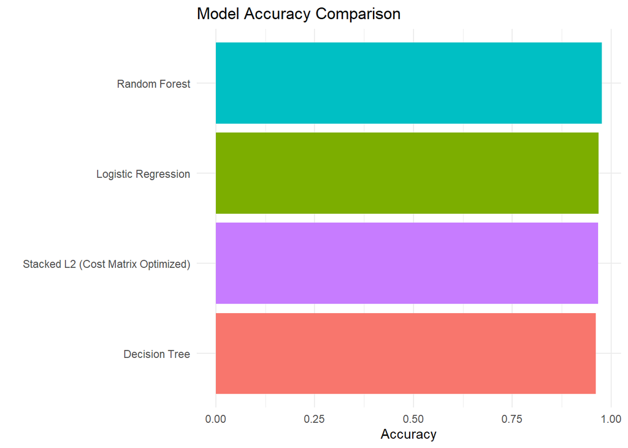

```r
ggplot(final_comparison, aes(x = reorder(Model, Accuracy), y = Accuracy, fill = Model)) +
  geom_col() +
  coord_flip() +
  labs(title = "Model Accuracy Comparison", x = "", y = "Accuracy") +
  theme_minimal() +
  theme(legend.position = "none")
```

Since we tried to optimize our model for precision, we compare **Precision**:

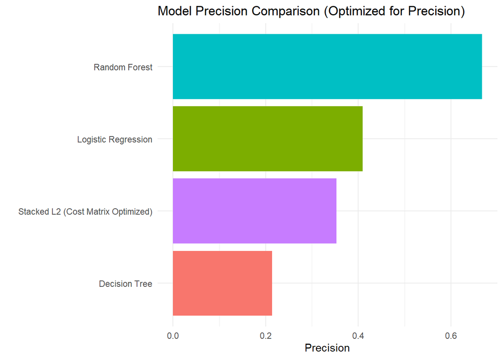

```r
ggplot(final_comparison, aes(x = reorder(Model, Precision), y = Precision, fill = Model)) +
  geom_col() +
  coord_flip() +
  labs(title = "Model Precision Comparison (Optimized for Precision)", x = "", y = "Precision") +
  theme_minimal() +
  theme(legend.position = "none")
```

Notice that even though with our cost matrix optimization on the stacked model, the Random Forest precision is still best. This is due to the fact that, as explained above, the cost matrix optimization can’t fine-tune precision beyond a certain point. We saw that the L2 model overfitted to the training data, and the Random Forest model was the best at generalizing to the test data (in terms of precision).

Before our presentation on Tuesday, we tried to optimize for Sensitivity, because we wanted to capture the opportunity cost of missing a team that could have made the final four. **Sensitivity**:

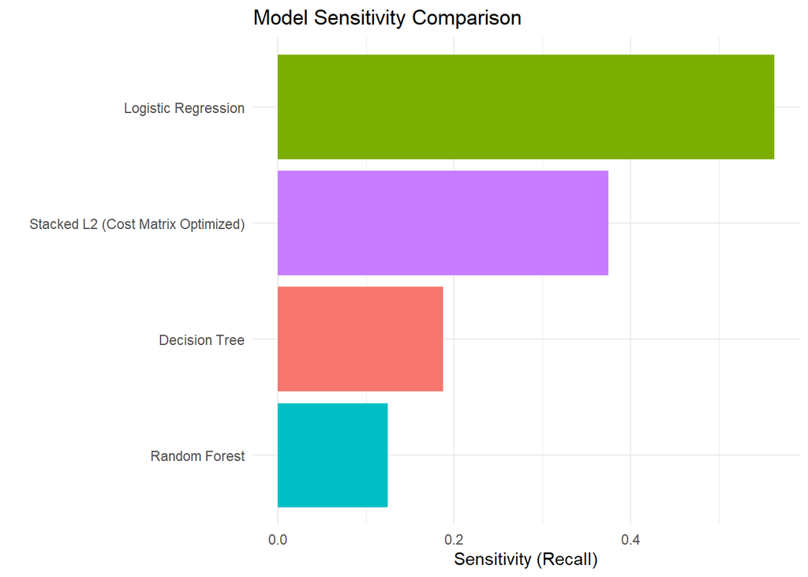

```r
ggplot(final_comparison, aes(x = reorder(Model, Sensitivity), y = Sensitivity, fill = Model)) +
  geom_col() +
  coord_flip() +
  labs(title = "Model Sensitivity Comparison", x = "", y = "Sensitivity (Recall)") +
  theme_minimal() +
  theme(legend.position = "none")
```

## 11 Conclusion: Betting Returns Analysis

We evaluated each model’s performance from a practical betting perspective. The betting strategy assumes:

For simplicity, we use $10 bets, with net profit of $20 for winning. This seemed to be relatively in line with what we observed the betting odds to be in real life.

```r
# Calculate betting returns for each model
calculate_betting_returns <- function(cm, model_name) {
  tp <- cm$table["Yes", "Yes"]
  fp <- cm$table["Yes", "No"]
  fn <- cm$table["No", "Yes"]
  tn <- cm$table["No", "No"]

  bet_per_prediction <- 10
  win_amount <- 20
  loss_amount <- -10

  num_bets <- tp + fp
  total_wins <- tp * win_amount
  total_losses <- fp * loss_amount
  net_profit <- total_wins + total_losses
  total_invested <- num_bets * bet_per_prediction
  roi <- ifelse(total_invested > 0, (net_profit / total_invested) * 100, 0)

  return(data.frame(
    Model = model_name,
    True_Positives = tp,
    False_Positives = fp,
    Total_Bets = num_bets,
    Total_Invested = total_invested,
    Total_Wins = total_wins,
    Total_Losses = total_losses,
    Net_Profit = net_profit,
    ROI_Percent = round(roi, 2),
    Precision = round(cm$byClass["Precision"], 3)
  ))
}
```

```r
betting_results <- rbind(
  calculate_betting_returns(cm_log, "Logistic Regression"),
  calculate_betting_returns(cm_dt, "Decision Tree"),
  calculate_betting_returns(cm_rf, "Random Forest"),
  calculate_betting_returns(l2_cm, "Stacked L2 Model")
)

kable(betting_results, digits = 2)
```

|  | Model | True_Positives | False_Positives | Total_Bets | Total_Invested | Total_Wins | Total_Losses | Net_Profit | ROI_Percent | Precision |
| --- | --- | --- | --- | --- | --- | --- | --- | --- | --- | --- |
| Precision | Logistic Regression | 9 | 13 | 22 | 220 | 180 | -130 | 50 | 22.73 | 0.41 |
| Precision1 | Decision Tree | 3 | 11 | 14 | 140 | 60 | -110 | -50 | -35.71 | 0.21 |
| Precision2 | Random Forest | 2 | 1 | 3 | 30 | 40 | -10 | 30 | 100.00 | 0.67 |
| Precision3 | Stacked L2 Model | 6 | 11 | 17 | 170 | 120 | -110 | 10 | 5.88 | 0.35 |

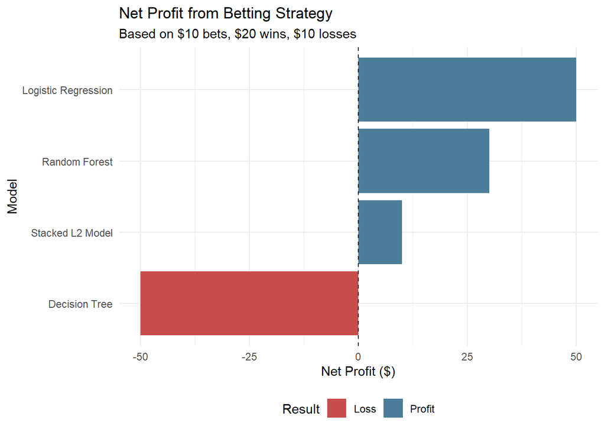

```r
ggplot(betting_results, aes(x = reorder(Model, Net_Profit), y = Net_Profit, fill = Net_Profit > 0)) +
  geom_col() +
  coord_flip() +
  scale_fill_manual(values = c("#C94C4C", "#4C7D99"), labels = c("Loss", "Profit"), name = "Result") +
  labs(
    title = "Net Profit from Betting Strategy",
    x = "Model",
    y = "Net Profit ($)",
    subtitle = "Based on $10 bets, $20 wins, $10 losses"
  ) +
  theme_minimal() +
  geom_hline(yintercept = 0, linetype = "dashed", color = "black") +
  theme(legend.position = "bottom")
```

```r
best_model <- betting_results[which.max(betting_results$Net_Profit), ]
best_model
```

```
##                         Model True_Positives False_Positives Total_Bets
## Precision Logistic Regression              9              13         22
##           Total_Invested Total_Wins Total_Losses Net_Profit ROI_Percent
## Precision            220        180         -130         50       22.73
##           Precision
## Precision     0.409
```

### Summary

After optimizing this model for precision, we actually saw through the data that the most sensitive models (Logistic Regression) were the ones that made the most money. Additionally, we determined that the best way to use the results was to combine what the model was creating with human intuition. This is because the model lacks context from certain variables (such as team injuries, hype, momentum, etc.) that humans can supplement via reading news, watching games, and more. Additionally, when the model was looking at sensitivity, it would occasionally flag teams that didn’t seem like they’d be predictably successful, which could be avoided if an avid fan’s judgment was also part of the decision-making process.

Also, to make best use of the model, fans should bet on teams the second the model starts picking up on potential success, because, unless fans are early movers, they will not be able to beat everyone else that is simultaneously noticing the new success of the team.